# In-class zonal and other stuff

# Today’s plan

- Zonal statistics
- Some “tips and tricks” with respect to data manipulation

# Packages

```r
library(tidyverse)
library(terra)
library(tidyterra)
library(sf)
```

```r
library(mapview)
```

# Read data

Read NLCD for northeast ohio

```r
neoh_lulc <- terra::rast("../data/ohio/neoh_nlcd.tif")

# summary
terra::summary(neoh_lulc)
```

```
##            NLCD.Land.Cover.Class
##  Open Water           :21768
##  Deciduous Forest     :20420
##  Unclassified         :14456
##  Hay/Pasture          :12179
##  Cultivated Crops     :10119
##  Developed, Open Space: 5850
##  (Other)              :15566
```

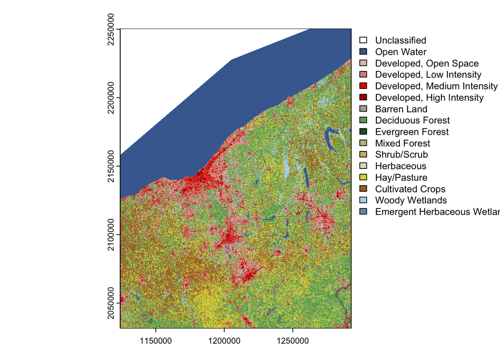

```r
# plot it
terra::plot(neoh_lulc)
```

Vector data

```r
# using terra vector classes to make later operations easier
# project to the crs of the raster so we don't need to resample raster (which takes forever)
neoh_counties <- vect("../data/ohio/neoh_counties.gpkg") %>%
  terra::project(., crs(neoh_lulc))

oh_tracts <- vect("../data/ohio/oh_tracts_2020.gpkg") %>%
  terra::project(., crs(neoh_lulc))
```

# let’s get some raster values

Test some zonal statistics. Wait, what’s a “zonal statistic”?

```r
test <- terra::zonal(neoh_lulc, neoh_counties)

test
```

| NLCD Land Cover Class |
| --- |
| 17.17970 |
| 52.91710 |
| 54.12369 |
| 66.21019 |
| 62.70240 |
| 35.33396 |
| 51.64419 |
| 49.34534 |
| 35.07226 |
| 49.72852 |

[output cut: 4 more lines]

What do we get?

```r
z.max <- terra::zonal(neoh_lulc, neoh_counties, fun = "max")
```

Useful?

In what context MIGHT it be useful?

Maybe not with categorical data

## Get values

Let’s try something a bit more intelligent

```r
values <- extract(neoh_lulc, neoh_counties)

values
```

| ID | NLCD Land Cover Class |
| --- | --- |
| 1 | Unclassified |
| 1 | Unclassified |
| 1 | Unclassified |
| 1 | Unclassified |
| 1 | Unclassified |
| 1 | Unclassified |
| 1 | Unclassified |
| 1 | Unclassified |
| 1 | Unclassified |
| 1 | Unclassified |

[output cut: 9990 more lines]

What do we get?. And… what’s with the tick marks around attribute #2?

```r
values %>% group_by(ID, `NLCD Land Cover Class`) %>%
  summarise(ncells = n())
```

[output not shown]

| ID | NLCD Land Cover Class | ncells |
| --- | --- | --- |
| 1 | Unclassified | 34175 |
| 1 | Open Water | 2123840 |
| 1 | Developed, Open Space | 99622 |
| 1 | Developed, Low Intensity | 149948 |
| 1 | Developed, Medium Intensity | 58918 |
| 1 | Developed, High Intensity | 19372 |
| 1 | Barren Land | 2752 |
| 1 | Deciduous Forest | 203780 |
| 1 | Evergreen Forest | 438 |
| 1 | Mixed Forest | 17497 |

[output cut: 204 more lines]

I would call the format of these data a “long data frame”… why?

# Let’s make a plan (or two):

1. Programatically create a list of distinct land cover classes

```r
# Starting with this object

values
```

| ID | NLCD Land Cover Class |
| --- | --- |
| 1 | Unclassified |
| 1 | Unclassified |
| 1 | Unclassified |
| 1 | Unclassified |
| 1 | Unclassified |
| 1 | Unclassified |
| 1 | Unclassified |
| 1 | Unclassified |
| 1 | Unclassified |
| 1 | Unclassified |

[output cut: 9990 more lines]

2. Which ID has the greatest total area of Barren Land

```r
# starting with this object

df.cells <- values %>% group_by(ID, `NLCD Land Cover Class`) %>%
  summarise(ncells = n())
```

[output not shown]

```r
df.cells %>%
  dplyr::ungroup() %>% # Why do i need to ungroup?
  dplyr::filter(`NLCD Land Cover Class` == "Barren Land") %>%
  dplyr::slice_max(., ncells, n = 1)
```

| ID | NLCD Land Cover Class | ncells |
| --- | --- | --- |
| 8 | Barren Land | 7699 |

2. Let’s find the county with the greatest fraction of forest.

What problems do we have?

Let’s break down the problems/tasks into (at least) 3 steps:

Don’t keep scrolling…

There are spoilers ahead….

No, really, we’re going to do this all together….

Why are you still scrolling?

I didn’t say it was ok just yet…

# Spoilers

All within a series of groups and summarise functions

```r
df.cells %>%
  group_by(ID) %>%
  mutate(tot_cells = sum(ncells)) %>%
  dplyr::filter(., str_detect(`NLCD Land Cover Class`, "Forest")) %>%
  group_by(ID) %>%
  summarise(forest_cells = sum(ncells),
            tot_cells = max(tot_cells)) %>%
  mutate(frac_forest = forest_cells/tot_cells)
```

| ID | forest_cells | tot_cells | frac_forest |
| --- | --- | --- | --- |
| 1 | 221715 | 2818271 | 0.07867057 |
| 2 | 545957 | 1450561 | 0.37637645 |
| 3 | 638193 | 1830376 | 0.34866771 |
| 4 | 267968 | 1602132 | 0.16725713 |
| 5 | 384496 | 1228322 | 0.31302541 |
| 6 | 832761 | 3937304 | 0.21150539 |
| 7 | 390309 | 1670441 | 0.23365626 |
| 8 | 375626 | 1223559 | 0.30699460 |
| 9 | 296830 | 2655511 | 0.11177886 |
| 10 | 576406 | 1175343 | 0.49041514 |

[output cut: 4 more lines]

```r
# make the data "wide"


df.cells.w <- df.cells %>% pivot_wider(id_cols = ID,
                                       names_from = `NLCD Land Cover Class`,
                                       values_from = ncells)

df.cells.w.calc <- df.cells.w %>%
  mutate(., )
```

```r
# get the vector data setup

neoh_counties.fix <- neoh_counties %>%
  tidyterra::mutate(., simpleid = seq(1:nrow(.))) %>%
  as_sf(.)
```

```r
# put it together

d.joined <- neoh_counties.fix %>% left_join(., df.cells.w, by = c("simpleid" = "ID"))
```

look up table to figure out which counties are which

eventually join back to the vector

Later we’ll do pivot longer and pivot wider